# Projekt

### Podgląd

```r
summary(data)
```

```
##    PATIENT_ID       RE_DATE                         age
##  Min.   :  1.0   Min.   :2020-01-10 19:45:00   Min.   :18.00
##  1st Qu.: 92.0   1st Qu.:2020-02-04 13:44:00   1st Qu.:47.00
##  Median :185.0   Median :2020-02-09 12:42:30   Median :62.00
##  Mean   :184.8   Mean   :2020-02-08 07:00:02   Mean   :59.44
##  3rd Qu.:270.0   3rd Qu.:2020-02-13 10:34:00   3rd Qu.:71.00
##  Max.   :375.0   Max.   :2020-02-18 17:49:00   Max.   :95.00
##                  NA's   :14
##      gender         outcome       Hypersensitive cardiac troponinI
##  Min.   :1.000   Min.   :0.0000   Min.   :    1.9
##  1st Qu.:1.000   1st Qu.:0.0000   1st Qu.:    4.4
##  Median :1.000   Median :0.0000   Median :   20.6
##  Mean   :1.391   Mean   :0.4747   Mean   : 1223.2
##  3rd Qu.:2.000   3rd Qu.:1.0000   3rd Qu.:  223.8
##  Max.   :2.000   Max.   :1.0000   Max.   :50000.0
##                                   NA's   :5613
##    hemoglobin    Serum chloride   Prothrombin time procalcitonin
##  Min.   :  6.4   Min.   : 71.50   Min.   : 11.50   Min.   : 0.020
##  1st Qu.:113.0   1st Qu.: 99.05   1st Qu.: 13.60   1st Qu.: 0.040
##  Median :125.0   Median :102.10   Median : 14.80   Median : 0.100
##  Mean   :123.1   Mean   :103.14   Mean   : 16.68   Mean   : 1.107
##  3rd Qu.:137.0   3rd Qu.:105.65   3rd Qu.: 16.70   3rd Qu.: 0.405
##  Max.   :178.0   Max.   :140.40   Max.   :120.00   Max.   :57.170
##  NA's   :5145    NA's   :5145     NA's   :5458     NA's   :5661
##  eosinophils(%)  Interleukin 2 receptor Alkaline phosphatase
##  Min.   :0.000   Min.   :  61.0         Min.   : 17.00
##  1st Qu.:0.000   1st Qu.: 459.5         1st Qu.: 54.00
##  Median :0.100   Median : 676.5         Median : 69.50
##  Mean   :0.629   Mean   : 907.2         Mean   : 82.47
##  3rd Qu.:0.800   3rd Qu.:1155.5         3rd Qu.: 95.00
##  Max.   :8.600   Max.   :7500.0         Max.   :620.00
##  NA's   :5163    NA's   :5852           NA's   :5190
##     albumin       basophil(%)   Interleukin 10    Total bilirubin
##  Min.   :13.60   Min.   :0.00   Min.   :   5.00   Min.   :  2.50
##  1st Qu.:27.40   1st Qu.:0.10   1st Qu.:   5.00   1st Qu.:  7.40
##  Median :32.20   Median :0.20   Median :   5.90   Median : 10.70
##  Mean   :32.01   Mean   :0.21   Mean   :  16.07   Mean   : 16.70
##  3rd Qu.:36.60   3rd Qu.:0.30   3rd Qu.:  12.35   3rd Qu.: 16.77
##  Max.   :48.60   Max.   :1.70   Max.   :1000.00   Max.   :505.70
##  NA's   :5186    NA's   :5163   NA's   :5853      NA's   :5190
```

[output cut: 169 more lines]

```
##  Min.   :   5.00               Min.   :  2.00   Min.   :  11.00
##  1st Qu.:  16.00               1st Qu.: 63.58   1st Qu.:  58.00
##  Median :  24.00               Median : 87.90   Median :  76.00
##  Mean   :  38.86               Mean   : 81.56   Mean   : 109.93
##  3rd Qu.:  41.00               3rd Qu.:103.97   3rd Qu.:  98.25
##  Max.   :1600.00               Max.   :224.00   Max.   :1497.00
##  NA's   :5189                  NA's   :5184     NA's   :5184
##     nRE_DATE         nAdmission time     nDischarge time
##  Min.   :1.579e+09   Min.   :1.579e+09   Min.   :1.580e+09
##  1st Qu.:1.581e+09   1st Qu.:1.581e+09   1st Qu.:1.582e+09
##  Median :1.581e+09   Median :1.581e+09   Median :1.582e+09
##  Mean   :1.581e+09   Mean   :1.581e+09   Mean   :1.582e+09
##  3rd Qu.:1.582e+09   3rd Qu.:1.581e+09   3rd Qu.:1.582e+09
##  Max.   :1.582e+09   Max.   :1.582e+09   Max.   :1.583e+09
##  NA's   :14
```

# Graficzna analiza

W tym kroku, w celu zapoznania się lepiej z danymi, został wygenerowany dla każdego atrybutu wykres zależności outcome od tego atrybutu. Poniżej kilka, moim zdaniem, najciekawszych wraz z komentarzem.

### Generowanie wszystkich wykresow

```r
options(repr.plot.width=16, repr.plot.height=10)

show <- function() {
    for (column_name in colnames(data)) {

        kv <- data %>%
                select(!!as.name(column_name), outcome) %>%
                filter(!is.na(!!as.name(column_name))) %>%
                count(!!as.name(column_name), outcome)

        print(ggplot(kv, aes(x=!!as.name(column_name), y=outcome, size = n))
              + geom_point(alpha=0.7)
              + ggtitle(paste("Zależnośc wyniku badania od atrybutu: ", column_name))
              + theme(text = element_text(size=20))
             )
    }
}

# Wywołanie zakomentowane ponieważ tylko część wykresów jest interesującą a są one opisane w następnej sekcji
# show()
```

### Najciekawsze wykresy

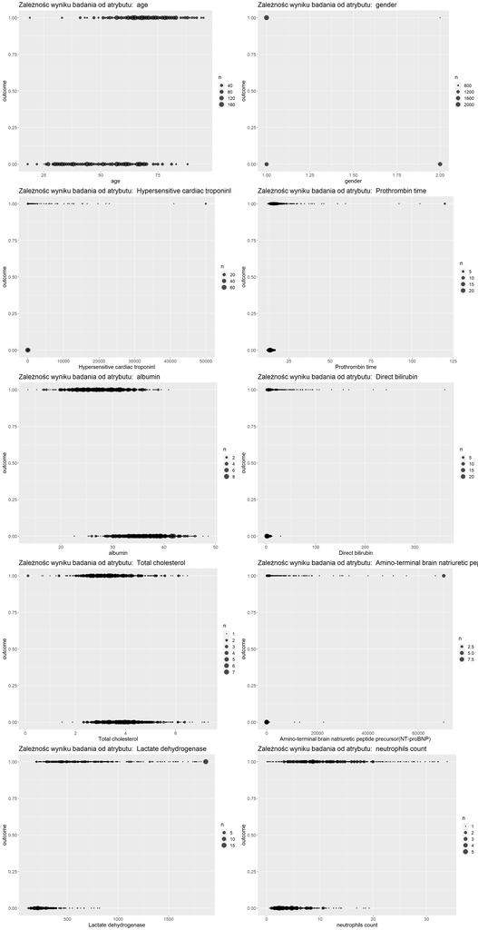

```r
ggarrange(
    plots[[1]],
    plots[[2]],
    plots[[3]],
    plots[[4]],
    plots[[5]],
    plots[[6]],
    plots[[7]],
    plots[[8]],
    plots[[9]],
    plots[[10]],
    ncol = 2, nrow = 5)
```

### Korelacje atrybutów

Z wygenerowanych wykresów można wyodrębnić te interesujące nie polegając na intuicji a wykorzystując współczynnik korelacji. Poniżej znajdują się posortowane wzgędem współczynnika korelacji wykresy zależności.

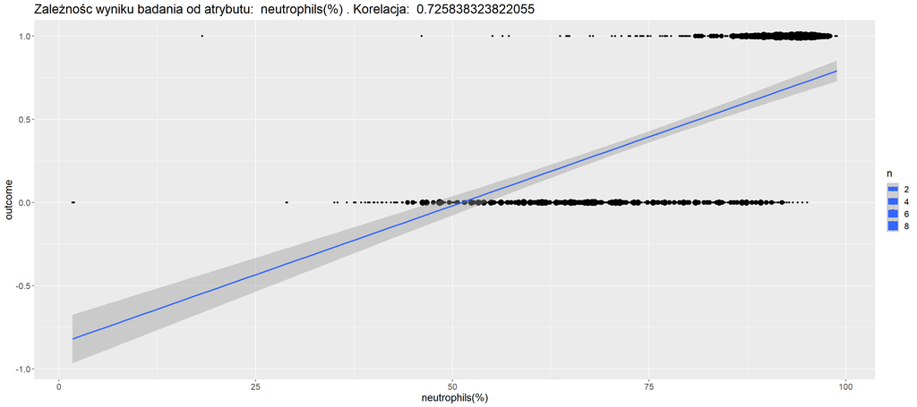

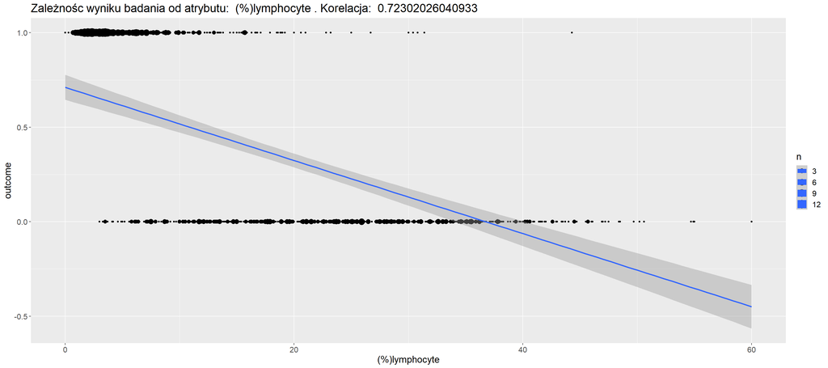

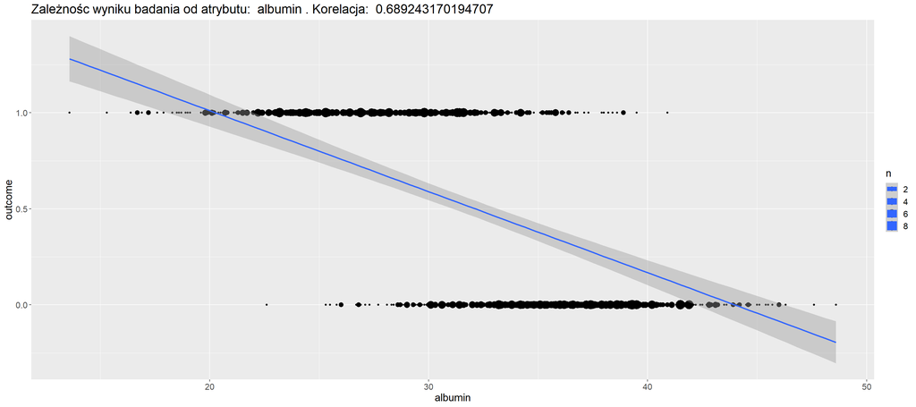

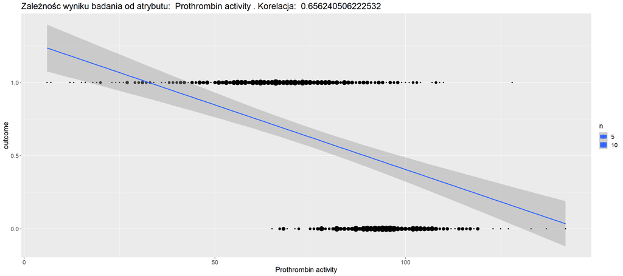

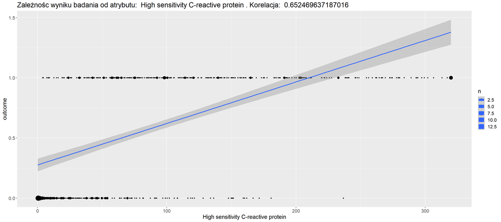

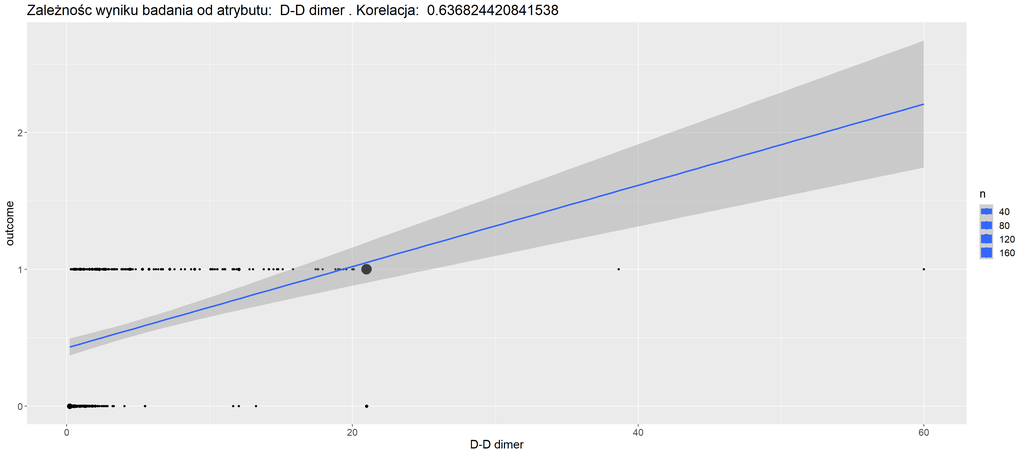

```r
korelacje = {}

for (column_name in colnames(select(data, -c("outcome", "PATIENT_ID", "RE_DATE")))) {
    kv <- data %>%
            select(!!as.name(column_name), outcome) %>%
            filter(!is.na(!!as.name(column_name)))

    korelacje[column_name] <- abs(cor(kv$outcome, kv %>% select(all_of(column_name))))
}

ordered <- korelacje[order(unlist(korelacje))]

options(repr.plot.width=16, repr.plot.height=6)
names <- names(rev(ordered))[1:6]

for (column_name in names) {
    kv <- data %>%
                select(!!as.name(column_name), outcome) %>%
                filter(!is.na(!!as.name(column_name))) %>%
                count(!!as.name(column_name), outcome)

    plot <- ggplot(kv, aes(x=!!as.name(column_name), y=outcome, size = n)) +
            geom_point() +
            geom_smooth(method="lm") +
            ggtitle(paste("Zależnośc wyniku badania od atrybutu: ", column_name, ". Korelacja: ", ordered[column_name])) +
            theme(text = element_text(size=15))

    suppressMessages(print(plot))
}
```

# Zmiana parametrów w czasie

Poza prostymi zależnościami pomiędzy współczynnikami krwi, a skutkiem choroby warto także zastanowić się nad wpływem choroby na zmiany tych współczynników. Wyniki poniższej analizy przedstawiąją zmianę parametrów krwi przed zgonem. Skrajny prawy słupek oznacza współczynniki krwi u pacjenta w dniu zgonu (dla wielu pomiarów wyciągana jest średnia). Przeciętnie, pacjenci trafiali do szpitala kilka dni przed zgonem, dlatego wyniki badań krwi pacjentów kilkanaście dni przed zgonem (lewa stronwa wykresu) są szczątkowe.

### Przygotowanie danych

```r
dead <- data %>%
            filter(outcome == 1) %>%
            select(c(1, 2, 5:(length(data) - 3) ))


patients_data = NA
initialized = FALSE

for (patient_id in dead$PATIENT_ID) {
    patient_data <- dead %>%
                    filter(PATIENT_ID==patient_id) %>%
                    mutate(day=format(RE_DATE, format='%m/%d/%Y')) %>%
                    group_by(day, PATIENT_ID) %>%
                    summarise_each(funs(mean(., na.rm = TRUE))) %>%
                    arrange(desc(RE_DATE))

    patient_data$day = seq.int(nrow(patient_data))

    if (!initialized) {
        patients_data = patient_data
        initialized =TRUE
    } else {
        patients_data = union(patients_data, patient_data)
    }

}
max_day <- max(patients_data["day"])
patients_data <- patients_data %>% select(c(1, 2, 5:length(patients_data)))
patients_data <- patients_data %>% mutate(day=(max_day - day + 1))
patients_data <- ungroup(patients_data)
```

Poniższy skrypt przedstawia sposób wygenerowania wszystkich wykresów. Podobnie jak w przypadku poprzedniej analizy, spośród wszystkich wybrane i zaprezentowane zostały te najbardziej interesujące.

### Generowanie danych

```r
options(repr.plot.width=16, repr.plot.height=10)
hide_cols = c("day", "PATIENT_ID")

show <- function(to_show) {
    for (column_name in to_show) {

        if (column_name %in% hide_cols) {
            next
        }

        kv <- patients_data %>%
                select(!!as.name(column_name), day) %>%
                filter(!is.na(!!as.name(column_name)))

        print(
                ggplot(kv, aes(x=day, y=!!as.name(column_name)))
              + geom_point()
              + ggtitle(paste("Zależnośc wyniku badania od atrybutu: ", column_name))
              + theme(text = element_text(size=20))
             )
    }
}

# show(colnames(patients_data))
```

### Najciekawsze wykresy

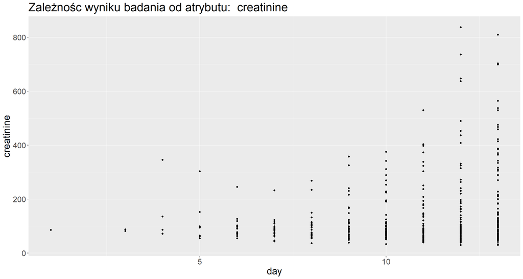

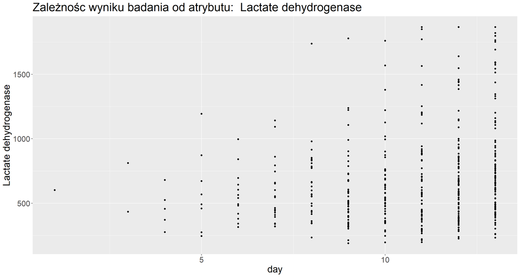

```r
options(repr.plot.width=15, repr.plot.height=8)

show(c("creatinine", "Lactate dehydrogenase"))
```

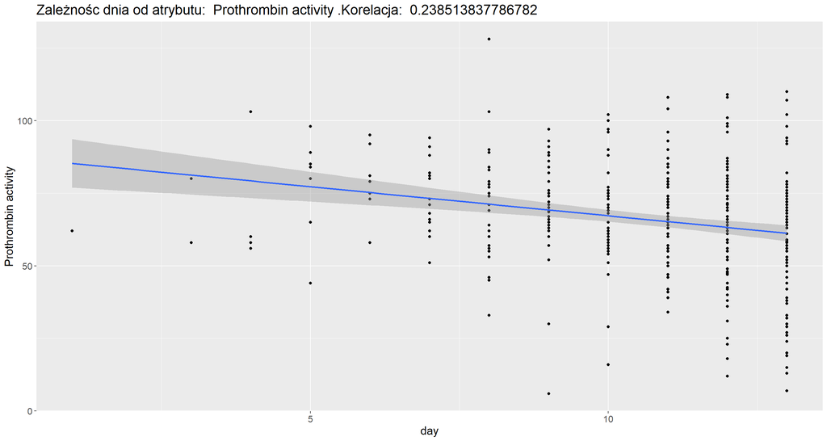

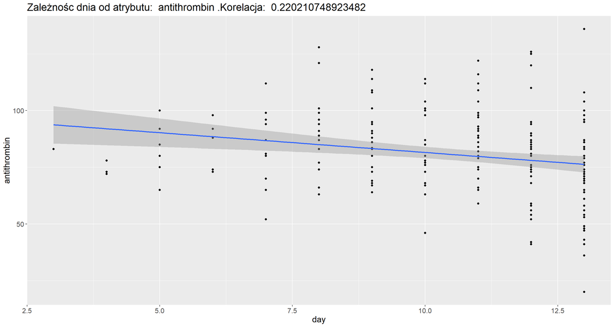

```r
korelacje = {}
hide_cols = c("day", "PATIENT_ID")

for (column_name in colnames(patients_data)) {

    if (column_name %in% hide_cols) {
        next
    }

    kv <- patients_data %>%
            select(!!as.name(column_name), day) %>%
            filter(!is.na(!!as.name(column_name)))



    korelacje[column_name] <- abs(cor(kv$day, kv %>% select(all_of(column_name))))
}

ordered <- korelacje[order(unlist(korelacje))]

options(repr.plot.width=16, repr.plot.height=6)
names <- names(rev(ordered))[1:2]

for (column_name in names) {
    kv <- patients_data %>%
                select(!!as.name(column_name), day) %>%
                filter(!is.na(!!as.name(column_name)))

    plot <- ggplot(kv, aes(x=day, y=!!as.name(column_name))) +
            geom_point() +
            geom_smooth(method="lm") +
            ggtitle(paste("Zależnośc dnia od atrybutu: ", column_name, ".Korelacja: ", ordered[column_name])) +
            theme(text = element_text(size=15))

    suppressMessages(print(plot))
}
```

Wskaźnik ten okazuje się niską korelacją.

# Klasyfikacja

W tej sekcji podjęto próbę utworzenia modelu klasyfikującego pacjentów ze względu na skutek choroby oraz dokonano oceny klasyfikatora.

### Przygotowanie danych do klasyfikacji

```r
# Usunięcie zbędnych kolumn
classification_data <- data %>%
        select(-c(`nAdmission time`, `nDischarge time`, `RE_DATE`, `nRE_DATE`))

# Zmiana typu columny outcome
i = 1
for (row in classification_data$outcome) {
    if (row==1) {
        classification_data$outcome[i] = "dead"
    } else {
        classification_data$outcome[i] = "alive"
    }

    i = i + 1
}

# Grupowanie danych i uśrednienie wyników
classification_data <- classification_data %>%
                        group_by(PATIENT_ID, outcome) %>%
                        summarise_each(funs(mean(., na.rm = TRUE))) %>%
                        ungroup() %>%
                        select(-c("PATIENT_ID"))
```

### Podział zbioru na 3 zbiory (treningowy, walidacyjny, testowy)

```r
set.seed(23)

inTraining <-
    createDataPartition(
        y = classification_data$outcome,
        p = .7,
        list = FALSE)

classification_data_training <- classification_data[ inTraining,]
nottraining  <- classification_data[-inTraining,]

inTesting <-
    createDataPartition(
        y = nottraining$outcome,
        p = .5,
        list = FALSE)

classification_data_testing = nottraining[inTesting, ]
classification_data_validating = nottraining[-inTesting, ]
```

### Uzupełnienie wartości pustych średnimi wartościami (osobno dla każdego zbioru)

```r
for(i in 4:ncol(classification_data_training)){
    mean <-  mean(classification_data_training[[i]], na.rm = TRUE)
    classification_data_training[is.na(classification_data_training[[i]]),i] <- mean
}

for(i in 4:ncol(classification_data_validating)){
    mean <-  mean(classification_data_validating[[i]], na.rm = TRUE)
    classification_data_validating[is.na(classification_data_validating[[i]]),i] <- mean
}

for(i in 4:ncol(classification_data_testing)){
    mean <-  mean(classification_data_testing[[i]], na.rm = TRUE)
    classification_data_testing[is.na(classification_data_testing[[i]]),i] <- mean
}
```

### Szukanie najlepszych parametrów dla algorytmu random forest

```r
set.seed(128)

control <- trainControl(
    method="repeatedcv",
    number=2,
    repeats=2,
    allowParallel = TRUE)

df <- data.frame(set=character(),
                 ntree=integer(),
                 mtry=integer(),
                 score=double(),
                 stringsAsFactors=FALSE)

for (ntree in c(5, 10, 15, 20, 25, 30)){

    for (mtry in c(1:10)) {
        set.seed(123);

        fit <- train(
            outcome ~ .,
            data = classification_data_training,
            method = "rf",
            trControl = control,
            metric='Accuracy',
            tuneGrid = expand.grid(mtry=c(mtry)),
            ntree = ntree
        )

        rfClasses <- predict(fit, newdata = classification_data_validating)
        rtClasses <- predict(fit, newdata = classification_data_training)
        fm <- confusionMatrix(table(rfClasses, classification_data_validating$outcome))
        tm <- confusionMatrix(table(rtClasses, classification_data_training$outcome))

        new_row <- data.frame("validating", mtry, ntree, fm$overall['Accuracy'])
        names(new_row)<-c("set", "mtry", "ntry", "score")
        df <- rbind(df, new_row)

        new_row <- data.frame("training", mtry, ntree, tm$overall['Accuracy'])
        names(new_row)<-c("set", "mtry", "ntry", "score")
        df <- rbind(df, new_row)
    }
}
```

### Wizualizacja zależności parametrów na jakość klasyfikacji

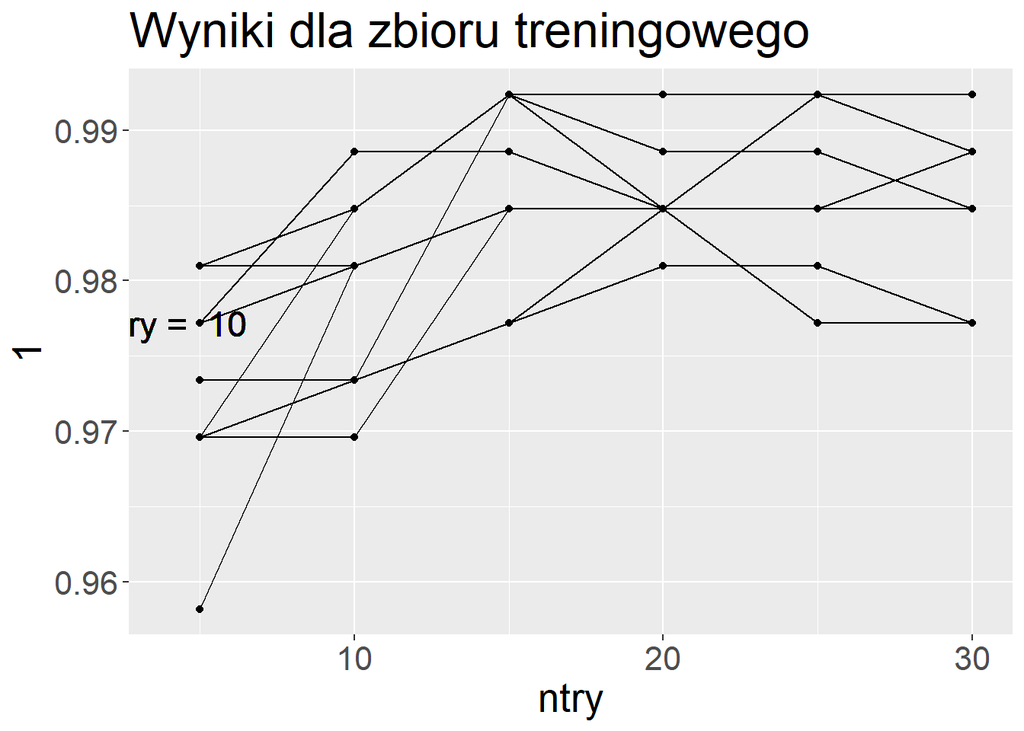

```r
dff <- df %>% mutate(grouped_id = row_number()) %>% spread('mtry', 'score')  %>%
            select(-c("grouped_id")) %>%
            group_by(set, ntry) %>%
            summarise_each(funs(mean(., na.rm = TRUE))) %>%
            ungroup()

vall <- dff %>% filter(set=="training")
plt <- ggplot(dff %>% filter(set=="training"), aes(x=ntry))

for (i in c(1:10)) {
    plt <- plt +
        geom_line(aes(y=!!as.name(i))) +
        geom_text(aes(x = 4, y = vall[[toString(i)]][[1]], label = paste("mtry = ", toString(i))), size=6) +
        geom_point(aes(y=!!as.name(i)))

}
print(plt + theme(text = element_text(size=20)) + ggtitle("Wyniki dla zbioru treningowego"))
```

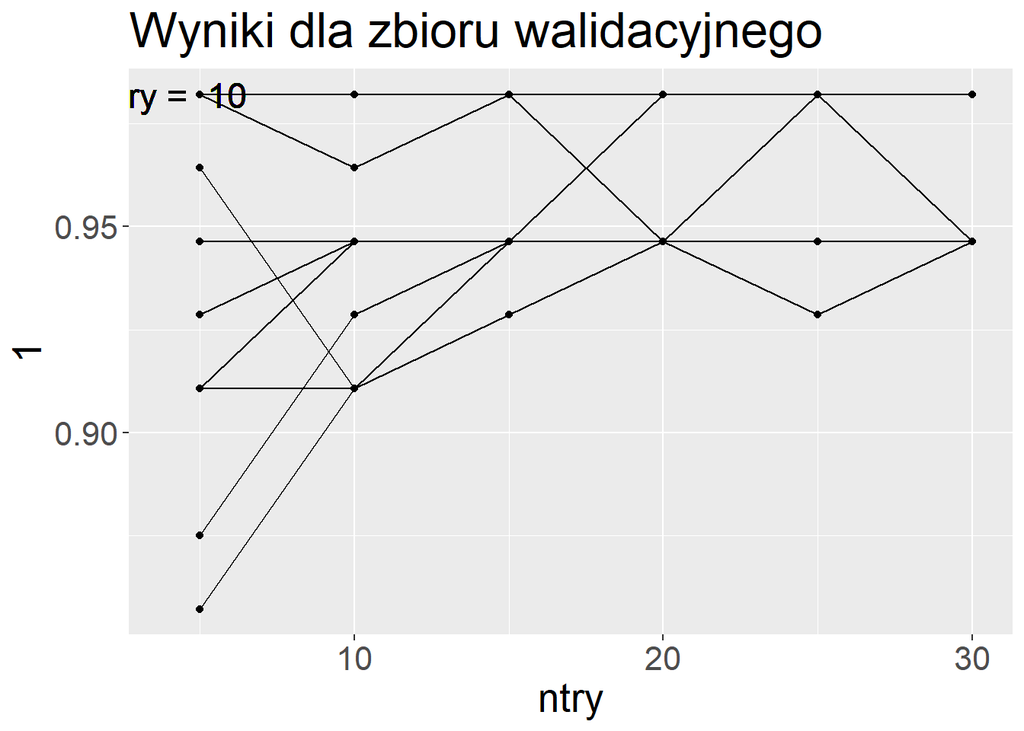

```r
vall <- dff %>% filter(set=="validating")
plt <- ggplot(vall, aes(x=ntry))

for (i in c(1:10)) {
    plt <- plt +
                geom_line(aes(y=!!as.name(i))) +
                geom_text(aes(x = 4, y = vall[[toString(i)]][[1]], label = paste("mtry = ", toString(i))), size=6) +
                geom_point(aes(y=!!as.name(i)))
}
print(plt + theme(text = element_text(size=20)) + ggtitle("Wyniki dla zbioru walidacyjnego"))
```

### Ocena klasyfikacji zbioru testowego

```r
fit <- train(
    outcome ~ .,
    data = classification_data_testing,
    method = "rf",
    trControl = control,
    metric='Accuracy',
    tuneGrid = expand.grid(mtry=c(3)),
    ntree = 30
)

confusionMatrix(table(rfClasses, classification_data_testing$outcome), positive="dead")$table
```

```
##
## rfClasses alive dead
##     alive    30    3
##     dead      0   23
```

```r
confusionMatrix(table(rfClasses, classification_data_testing$outcome))$overall['Accuracy']
```

```
##  Accuracy
## 0.9464286
```

```r
confusionMatrix(table(rfClasses, classification_data_testing$outcome))$byClass['Pos Pred Value']
```

```
## Pos Pred Value
##      0.9090909
```

```r
confusionMatrix(table(rfClasses, classification_data_testing$outcome))$byClass['Neg Pred Value']
```

```
## Neg Pred Value
##              1
```

### Wybrane miary klasyfikacji to:

- Macierz pomyłek, pokazuje dokładnie (nie tylko procentowo) dokonane błędy
- Skuteczność pozwala porównywać bezpośrednio 2 wyniki algorytmu jednym współczynnikiem
- Pos Pred Value i Neg Pred Value - podobnie jak wyżej, jednak ze względu na specyfikę problemu, prawodopodobnie bardziej istotne będzie maksymalizowanie wskaźnika Pos Pred Value

### Ocena ważności współczynników w klasyfikatorze

```r
varImp(fit)
```

```
## rf variable importance
##
##   only 20 most important variables shown (out of 75)
##
##                                                                 Overall
## `Lactate dehydrogenase`                                          100.00
## `Prothrombin time`                                                98.20
## `D-D dimer`                                                       65.19
## calcium                                                           62.37
## `neutrophils count`                                               53.84
## `neutrophils(%)`                                                  46.74
## `Platelet count`                                                  40.19
## `Prothrombin activity`                                            39.13
## `High sensitivity C-reactive protein`                             30.18
## `Eosinophil count`                                                30.06
## `lymphocyte count`                                                29.72
## `eosinophils(%)`                                                  29.59
## glucose                                                           26.32
## `White blood cell count`                                          25.58
## globulin                                                          25.18
## ferritin                                                          23.89
## `HCO3-`                                                           23.79
## `Amino-terminal brain natriuretic peptide precursor(NT-proBNP)`   22.92
## procalcitonin                                                     22.73
## albumin                                                           20.30
```